# Introduction

During Covid there are many industries that were affected by the event, one of them that was significantly impacted was the airline/aerospace industry. Many companies was bailed by the U.S government, one of the example was Delta Airline. In addition, people may have the assumption that only airlines companies were negatively impacted because in this industry only commercial airlines are being reported by the media. Airports also generates income from airlines companies, by grounded, landing fees, terminal rentals. late fees, and etc. On the other hand, how was aerospace companies that provide the newest infrastructure in this field were impacted for example Boeing, Airbus, Lockheed Martin, General Motor, and etc. Most of the public have knowledge for Boeing and Airbus due to their popularity in planes among the commercial airlines. On the other hand, many individual will be surprised that General Motor actually makes plane’s engines, in another word planes part are made by different companies, then assembled by another as a final product. Furthermore, this industry was heavily commercialized only after World War II, therefore, it will be interesting to observe how this industry has evolved.

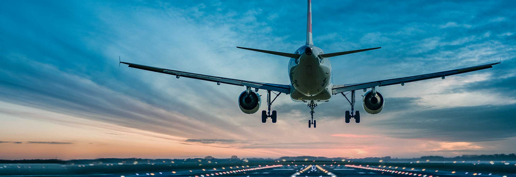

1. How are the airlines companies stock price affected by world major events?
2. What are the public sentiment about air travel after Covid
3. Can airlines prevent delay arrival or departure?
4. Do the demand of travel have increased after Covid?
5. How does airlines predict seasonal sales?
6. What are the main causes of delay and baggage lost?
7. Do infrastructure of the airport impact airlines punctuality?
8. Does travel industry is correlated with the airline industry?
9. How does air traffic technology improvement impact on airlines and punctuality over the year?
10. How has safety performance in aviation changed over the years?

[figure not shown]

# Welcome aboard on this project and please fasten your seatbelt!